# Welcome to my 2022 Projections for Pitchers 6x6

Darshan Patel

2022-03-30

Projections using Hypertuned model through XGboost

All data is from [FanGraphs.](https://www.fangraphs.com/) I have no affiliation with FanGraphs, but please consider contributing to their [website](https://plus.fangraphs.com/shop/) if you found this project informative.

# 1 Project Scope

## 1.1 Objective

This project is designed to showcase how Using a Percentile Based Worth System values Fantasy Baseball Players through a Inning Pitched (IP) weighted projection

The Categories used for prediction valuation are year-end rankings for the following metrics:

- Wins
- Saves
- Strike Outs
- ERA ( 9 * Earned Runs per Inning Pitched)
- WHIP (Walks and Hits per Inning Pitched)
- Holds

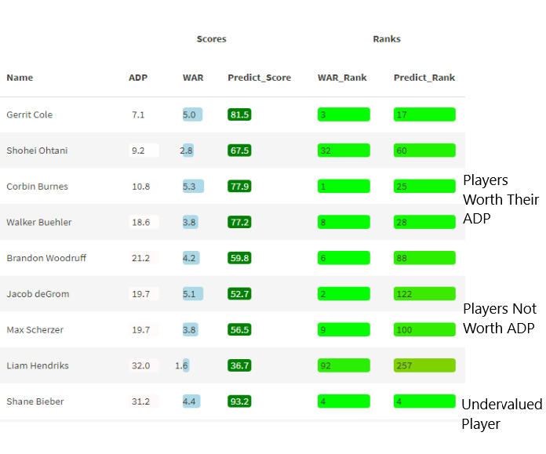

# 2 Processing the Data

## 2.1 Getting Data Into R

### 2.1.1 Load Libraries

*First we need to load the packages that R needs to run the analysis*

```r
library(sqldf) #SQL in R
library(skimr) #Summaries and useful for removing low % data
library(ggplot2) #Plotting Functions
library(plyr) #slightly deprecated data cleaning
library(dplyr) #slightly updated data cleaning
library(tidyverse) #tidyverse data cleaning universe
library(caret) #wrapper for creating, tuning and validating models
library(xgboost) #package for creating regression tree model
library(vtreat) # useful package for treating data before modeling
library(Matrix) #creating matricies for xgboost
library(mgcv)
library(moments) #for measuring skewness
library(data.table) #alternative to dplyr we use to create lags
library(pdp) #partial dependence graphs
library(vip) #variable importance
library(grid) #put multiple plots on one grid
library(gridExtra) #additional grid functionality
library(janitor) #one function used to clean transposed data set
library(ggpubr) #for qq plot
library(owmr) #Removing Prefixes
library(kableExtra) # formatting HTML Tables
library(formattable) # formatting HTML Tables
```

The # comments generally explain what additional functionality each library adds to R

### 2.1.2 Load in Data

All data is downloaded from Fan Graphs from this [location](https://www.fangraphs.com/leaders.aspx?pos=all&stats=pit&lg=all&qual=0&type=7&season=2021&month=0&season1=2015&ind=1&team=0&rost=0&age=0&filter=&players=0&startdate=2015-01-01&enddate=2021-12-31). The data is also available on my Github [here](https://github.com/dissipation/Fantasy-Baseball). There are player level and team data sets

```r
#data read-in
pitcher_data <- read_csv("FanGraphs Leaderboard_Pitching20IP.csv")
```

```r
#Team datasets
FDG_Team = read_csv("FanGraphs Leaderboard_Team.csv")
```

```r
#Create a prefix for all team stats that starts with T_
FDG_Team2 <- FDG_Team %>%
  rename_with( ~ paste0("T_", .x))
```

### 2.1.3 Checking Team Data

`str` give information about an object, while `skim` provides a customizable summary

```r
#Output not shown for space
#str(FDG_Team2)

skim(FDG_Team2) %>%
  tibble::as_tibble() #Remove this option for a normal HTML table
```

| skim_type | skim_variable | n_missing | complete_rate | character.min | character.max | character.empty | character.n_unique | character.whitespace | logical.mean | logical.count | numeric.mean | numeric.sd | numeric.p0 | numeric.p25 | numeric.p50 | numeric.p75 | numeric.p100 | numeric.hist |
| --- | --- | --- | --- | --- | --- | --- | --- | --- | --- | --- | --- | --- | --- | --- | --- | --- | --- | --- |
| character | T_Team | 0 | 1.000 | 3 | 3 | 0 | 30 | 0 | NA | NA | NA | NA | NA | NA | NA | NA | NA | NA |
| character | T_BB% | 0 | 1.000 | 4 | 5 | 0 | 48 | 0 | NA | NA | NA | NA | NA | NA | NA | NA | NA | NA |
| character | T_K% | 0 | 1.000 | 5 | 5 | 0 | 86 | 0 | NA | NA | NA | NA | NA | NA | NA | NA | NA | NA |
| character | T_LD% | 0 | 1.000 | 5 | 5 | 0 | 45 | 0 | NA | NA | NA | NA | NA | NA | NA | NA | NA | NA |
| character | T_GB% | 0 | 1.000 | 5 | 5 | 0 | 88 | 0 | NA | NA | NA | NA | NA | NA | NA | NA | NA | NA |
| character | T_FB%...45 | 0 | 1.000 | 5 | 5 | 0 | 92 | 0 | NA | NA | NA | NA | NA | NA | NA | NA | NA | NA |
| character | T_IFFB% | 0 | 1.000 | 4 | 5 | 0 | 60 | 0 | NA | NA | NA | NA | NA | NA | NA | NA | NA | NA |
| character | T_HR/FB | 0 | 1.000 | 4 | 5 | 0 | 96 | 0 | NA | NA | NA | NA | NA | NA | NA | NA | NA | NA |
| character | T_IFH% | 0 | 1.000 | 4 | 4 | 0 | 41 | 0 | NA | NA | NA | NA | NA | NA | NA | NA | NA | NA |
| character | T_BUH% | 0 | 1.000 | 4 | 5 | 0 | 158 | 0 | NA | NA | NA | NA | NA | NA | NA | NA | NA | NA |

[output cut: 307 more lines]

## 2.2 Understanding the Dataset

### 2.2.1 Exploring the dataset

`skim` let’s us see how the data was imported into R. Documentation can be found [here](https://cran.r-project.org/web/packages/skimr/vignettes/skimr.html)

```r
#Full Dataset dimensions

skimr::skim(pitcher_data) %>%
  tibble::as_tibble() %>%  #Remove this option for a normal HTML table
  select(skim_type,skim_variable,complete_rate) %>%
  filter(complete_rate >0.30) #250 Variables
```

| skim_type | skim_variable | complete_rate |
| --- | --- | --- |
| character | Name | 1.00 |
| character | Team | 1.00 |
| character | LOB% | 1.00 |
| character | LD% | 1.00 |
| character | GB% | 1.00 |
| character | FB%...50 | 1.00 |
| character | IFFB% | 1.00 |
| character | HR/FB | 1.00 |
| character | IFH% | 1.00 |
| character | BUH% | 1.00 |

[output cut: 240 more lines]

```r
#skim_type - character or numeric
#skim_variable - name of variable
#complete_rate - % of data that is not missing
#filter - only keep variables that have 30% of data populated
```

Additionally let’s look at how variables vary by year to see if there are any discrepancies there

```r
#It looks like one year, there were fewer games played, and there is a clear drop off in home runs
pitcher_data_dist =
pitcher_data %>%
 group_by(Season) %>%
  summarize (Max_Games = max(G),
             Avg_W= mean(W)
             )

pitcher_data_dist
```

| Season | Max_Games | Avg_W |
| --- | --- | --- |
| 2014 | 80 | 5.0 |
| 2015 | 81 | 4.6 |
| 2016 | 82 | 4.6 |
| 2017 | 79 | 4.5 |
| 2018 | 82 | 4.5 |
| 2019 | 83 | 4.3 |
| 2020 | 32 | 2.3 |
| 2021 | 81 | 4.2 |

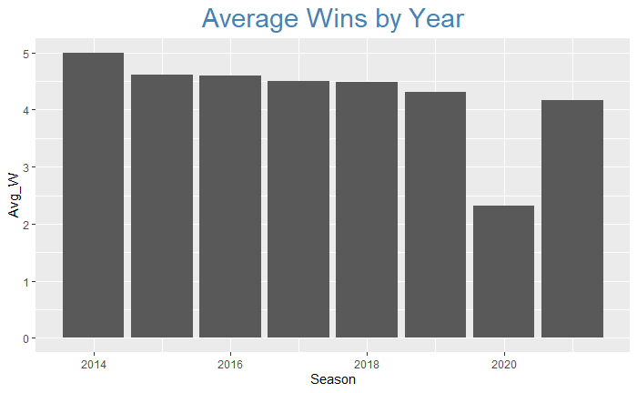

```r
#Plot Win Data by Year
ggplot(pitcher_data_dist, aes(Season, Avg_W)) +
  geom_col()+
  ggtitle("Average Wins by Year")+
  theme(plot.title = element_text(hjust = 0.5,size = 22,color ="steel blue"))
```

## 2.3 Cleaning and Creating Initial Dataset for Model

What are some issues with the data?

1. Many of Variables, such as K%, are being read in as characters
   - Only Team and Player Name should be characters
2. There is spotty data coverage in some of the variables (~Variables have less than 30% Coverage)
3. 2020 Data only includes 60 games worth of data
   - This was a season shortened due to Covid-19
4. Team Data needs to be appended to pitcher Data by Team Name

### 2.3.1 Cleanly Changing all Variables that are characters to numeric.

There are several ways to do this, we will identify the variables we want to change that are mis-identified. `parse_number` can be used to pull numbers from these variables. Additional ways to tackle this can be found [here.](https://stackoverflow.com/questions/8329059/how-to-convert-character-of-percentage-into-numeric-in-r)

```r
#Select Column names that are characters but not Team or Name, These should be percentages
pitcher_data_chars_to_convert <- pitcher_data %>%
  select_if(is.character)%>% select(-Team,-Name) %>%
  mutate_all (function(x) as.numeric(readr::parse_number(x))/100)
#Note : There are additional ways to do this, this is just one solution


#We can exclude the variables we converted and reintroduce them
pitcher_data_num <- pitcher_data %>% select(-colnames(pitcher_data_chars_to_convert))

pitcher_data2 = cbind(pitcher_data_num,pitcher_data_chars_to_convert) %>%
  select (colnames(pitcher_data)) %>%  #preserve original order
  dplyr::rename(flyball_perc = `FB%...50`,fastball_perc = `FB%...74`) #rename two ambiguous columns

skim(pitcher_data2) %>%
  as_tibble() %>%
  group_by(skim_type) %>%
  count()
```

| skim_type | n |
| --- | --- |
| character | 2 |
| logical | 3 |
| numeric | 326 |

```r
#Logical variables are R's best guess, in our case they are all NA's and will be removed at a later step
```

The same can be done for the Team Data that is loaded

```r
#Select Column names that are characters but not Team or Name, These should be percentages
FDG_Team2_chars_to_convert <- FDG_Team2 %>%
  select_if(is.character)%>% select(-T_Team) %>%
  mutate_all (function(x) as.numeric(readr::parse_number(x))/100)
#Keep in mind, parse number may make actual characters into numerical variables so carefully check your data before using

#We can exclude the variables we converted and reintroduce them
FDG_Team2_num <- FDG_Team2 %>% select(-colnames(FDG_Team2_chars_to_convert))

FDG_Team3 = cbind(FDG_Team2_num,FDG_Team2_chars_to_convert) %>%
  select (colnames(FDG_Team2)) %>%  #preserve original order
dplyr::rename(T_flyball_perc = `T_FB%...45`,T_fastball_perc = `T_FB%...72`)  #rename two ambiguous columns

skim(FDG_Team3) %>%
  as_tibble() %>%
  group_by(skim_type) %>%
  count()
```

| skim_type | n |
| --- | --- |
| character | 1 |
| logical | 6 |
| numeric | 310 |

### 2.3.2 Filtering Data with Low Coverage

I choose 30% coverage of data necessary but this can be adjusted up or down. This will also get rid of columns that are all `NA`.

```r
# Keep variables with enough values (Need 30% data coverage rate here)
Player_cols_to_keep =
skim(pitcher_data2) %>%
  dplyr::select(skim_type, skim_variable, complete_rate) %>%
  filter (complete_rate > 0.30)

#Transpose Rows to get column names as skim melts the data
Player_cols_to_keep_transpose = t(Player_cols_to_keep)

#extract the colnames we would like to keep
Player_cols_to_keep = colnames(janitor::row_to_names(Player_cols_to_keep_transpose,row_number = 2))

#Only keep the columns designated to have over 30% of their data populated or greater
pitcher_data3 = pitcher_data2 %>%
  select(one_of(Player_cols_to_keep))
```

*Repeat the process for Team Variables*

```r
Team_cols_to_keep =
skim(FDG_Team3) %>%
  dplyr::select(skim_type, skim_variable, complete_rate) %>%
  filter (complete_rate > 0.30)


#Transpose Rows to get column names as skim melts the data
Team_cols_to_keep_transpose = t(Team_cols_to_keep)

#extract the colnames we would like to keep
Team_cols_to_keep = colnames(janitor::row_to_names(Team_cols_to_keep_transpose,row_number = 2))

#Only keep the columns designated to have over 30% of their data populated or greater
FDG_Team4 = FDG_Team3 %>%
  select(one_of(Team_cols_to_keep))
```

### 2.3.3 Creating Variables Normalized by Year

Some Variables will need to be normalized by Innings_Pitched (IP) if they aren’t a percentage already. Remaining Variables are percentages or indices so will not need to be transformed. The full data dictionary for these variables can be found on FanGraph’s website [here.](https://library.fangraphs.com/pitching/complete-list-pitching/) for pitching variables and [here.](https://library.fangraphs.com/offense/offensive-statistics-list/) for hitting variables.

```r
pitcher_data4 = pitcher_data3 %>%
  mutate( #create new variables based on existing variables
    W_IP = W/IP,
    L_IP =  L/IP,
    ShO_IP = ShO/IP,
    SV_IP = SV/IP,
    BS_IP = BS/IP,
    TBF_IP = TBF/IP,
    H_IP = H/IP,
    R_IP = R/IP,
    ER_IP = ER/IP,
    HR_IP=HR/IP,
    BB_IP=BB/IP,
    IBB_IP=IBB/IP,
    HBP_IP=HBP/IP,
    WP_IP= WP/IP,
    BK_IP=BK/IP,
    SO_IP=SO/IP,
    GB_IP = GB/IP,   #Groundballs
    FB_IP =  FB/IP,  #FlyBalls
    LD_IP = LD/IP,   #LineDrives
    IFFB_IP = IFFB/IP,  #Infield Fly balls
    Balls_IP= Balls/IP,
    Strikes_IP= Strikes/IP,
    Pitches_IP= Pitches/IP,
    RS_IP= RS/IP,
    IFH_IP= IFH/IP,
    BU_IP= BU/IP,
    BUH_IP= BUH/IP,
    Pulls_IP= Pulls/IP,
    HLD_IP= HLD/IP,
    SD_IP= SD/IP,
    MD_IP= MD/IP,
    Barrels_IP= Barrels/IP,
    HardHits_IP= HardHit/IP
  ) %>% select(-L,-G,-IP,-ShO,-BS,-(TBF:BK),-(GB:BUH),-Pulls,-(SD:MD),-Barrels,-HardHit,-Events)

#will be removed after data is lagged -FIP,-(RAR:WPA),,-(wFB:wCH),-(`ERA-`:`xFIP-`),-SIERA,-(`RA9-WAR`:`Age Rng`),-kwERA,-`wCH (pi)`:`wSL (pi)`,`K/9+`:`HR/FB%+`)

#skim(pitcher_data4) %>% as_tibble()
```

*Repeat the process for Team Variables*

```r
FDG_Team5 = FDG_Team4 %>%
  mutate( #create new variables based on existing variables
    T_H_T_PA = T_H/T_PA,
    T_x1B_T_PA = T_1B/T_PA, #note: R can't have variables start with a number
    T_x2b_T_PA = T_2B/T_PA,
    T_x3b_T_PA = T_3B/T_PA,
    T_HR_T_PA = T_HR/T_PA,
    T_R_T_PA = T_R/T_PA,
    T_RBI_T_PA = T_RBI/T_PA,
    T_BB_T_PA = T_BB/T_PA,
    T_IBB_T_PA = T_IBB/T_PA,
    T_SO_T_PA=T_SO/T_PA,
    T_HBP_T_PA=T_HBP/T_PA,
    T_SF_T_PA=T_SF/T_PA,
    T_SH_T_PA=T_SH/T_PA,
    T_GDP_T_PA= T_GDP/T_PA,#ground into double play
    T_SB_T_PA=T_SB/T_PA,
    T_CS_T_PA=T_CS/T_PA,
    T_GB_T_PA = T_GB/T_PA,   #Groundballs
    T_FB_T_PA =  T_FB/T_PA,  #FlyBalls
    T_LD_T_PA = T_LD/T_PA,   #LineDrives
    T_IFFB_T_PA = T_IFFB/T_PA,  #Infield Fly balls
    T_Pitches_T_PA= T_Pitches/T_PA,
    T_Balls_T_PA= T_Balls/T_PA,
    T_Strikes_T_PA= T_Strikes/T_PA,
    T_IFH_T_PA= T_IFH/T_PA,
    T_BU_T_PA= T_BU/T_PA,
    T_BUH_T_PA= T_BUH/T_PA,
    T_PH_T_PA= T_PH/T_PA,
    T_Barrels_T_PA= T_Barrels/T_PA,
    T_HardHits_T_PA= T_HardHit/T_PA
  ) %>% select(-(T_H:T_CS),-(T_GB:T_BUH),-T_PH,-T_Barrels,-T_HardHit,-T_Events) #Drop the old variables


#skim(FDG_Team5) %>% as_tibble()
```

### 2.3.4 Creating Lagged Variables

There are several ways to lag a dataset **BY GROUP**.  
* `Dplyr` way is [here.](https://statisticsglobe.com/create-lagged-variable-by-group-in-r).  
* The `data.table` (the method used below) is [here.](https://stackoverflow.com/questions/26291988/how-to-create-a-lag-variable-within-each-group)

```r
#Note we will only be lagging the player level data, as the previous year's team performance shouldn't impact current performance


#Order the dataset by lag columns
pitcher_data5 =  arrange(pitcher_data4, playerid,Season) #playerid is the Fangraph id assigned to each player

# Convert dataframe to data.table format
DT_pitcher = data.table(pitcher_data5)

#designate columns to lag - which is all of them
cols1 = colnames(pitcher_data5)
anscols = paste("lag", cols1, sep="_")
DT_pitcher[, (anscols) := data.table::shift(.SD, 1, NA, "lag"),by ='playerid', .SDcols=cols1] #Create 1 period lags by year

pitcher_data6 = as.data.frame(DT_pitcher) %>% select(-lag_playerid, -lag_Team, -lag_Season, -lag_Age,-lag_Name)

ncol(pitcher_data5) #251 - no lags
```

```
[1] 251
```

```r
ncol(pitcher_data6) #497 - lagged data ~ (251 * 2)-5
```

```
[1] 497
```

### 2.3.5 Merging Team and Player Data

We can use either the `merge` function or the SQL functionality provided by the `sqldf` package to join the lagged player level data to the Team level data

```r
df_pitching_init = sqldf(
  "
  select a.*, b.*
  from pitcher_data6 a
  left join FDG_Team5 b
  on a.Team = b.T_Team and a.Season = b.T_Season

  "
)  %>% select(-T_Team,-T_Season,-T_Age,-T_G,-T_AB)# Unncessary Team Variables


nrow(df_pitching_init) - nrow(pitcher_data6) #check if any rows are duplicated
```

```
[1] 0
```

# 3 Creating Rankings for Players Based On Percentiles

We can use Percentile based ranking to get rankings for players from the 2021 season.

## 3.1 Worth of each stat

### 3.1.1 Calculating past performance

```r
#Categories I include are:
#Wins, Saves, WHIP, ERA, SOs, Holds

df_pitching_init2 =  df_pitching_init %>%
#  arrange(player_id,year) %>%
  group_by(Season) %>%
  mutate(
    Wins_share = order(order(rank(W_IP,ties.method = 'average'),decreasing = FALSE))/n(),
     SO_share = order(order(rank(SO_IP,ties.method = 'average'),decreasing = FALSE))/n(),
     SV_share = order(order(rank(SV_IP,ties.method = 'average'),decreasing = FALSE))/n(),
     WHIP_share = order(order(rank(WHIP,ties.method = 'average'),decreasing = FALSE))/n(),
     ERA_share = order(order(rank(ERA,ties.method = 'average'),decreasing = FALSE))/n(),
    HLD_share = order(order(rank(HLD_IP,ties.method = 'average'),decreasing = FALSE))/n(),
    Worth = Wins_share+SO_share+SV_share+WHIP_share+ERA_share+HLD_share
    ) %>%
  ungroup()
```

Chart of the Distribution of initial percentiles  
As the chart below shows, the data is roughly normal.

```r
skewness((df_pitching_init2$Worth))
```

```
[1] 0.1
```

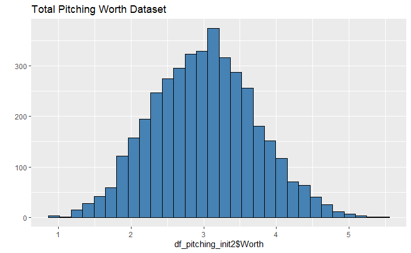

```r
ggplot2::qplot(df_pitching_init2$Worth, main="Total Pitching Worth Dataset") + geom_histogram(colour="black", fill="steelblue")
```

```r
min(df_pitching_init2$Worth)
```

```
[1] 0.88
```

```r
max(df_pitching_init2$Worth)
```

```
[1] 5.4
```

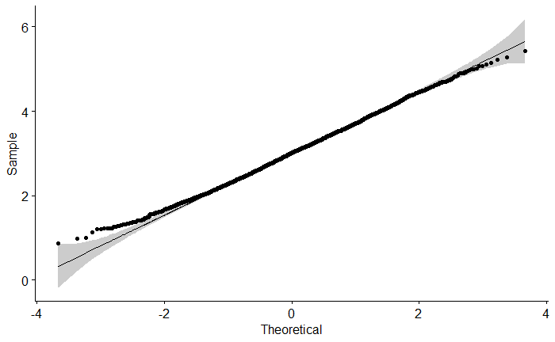

```r
ggpubr::ggqqplot(df_pitching_init2$Worth)
```

```r
shapiro.test(df_pitching_init2$Worth)
```

```
    Shapiro-Wilk normality test

data:  df_pitching_init2$Worth
W = 1, p-value = 0.0003
```

Total Rankings for the players (Using 6x6 Scoring) can be found here. While it looks like many of the top players have low worth scores, it is because we haven’t applied a modifier for IP yet. Wins are harder to come by relative to any other stat and require more innings pitched.

```r
df_pitching_init2_raw =  df_pitching_init %>%
#  arrange(player_id,year) %>%
  group_by(Season) %>%
  mutate(
    Wins_share_raw = order(order(rank(W,ties.method = 'average'),decreasing = FALSE))/n(),
     SO_share_raw = order(order(rank(SO,ties.method = 'average'),decreasing = FALSE))/n(),
     SV_share_raw = order(order(rank(SV,ties.method = 'average'),decreasing = FALSE))/n(),
     WHIP_share = order(order(rank(WHIP,ties.method = 'average'),decreasing = FALSE))/n(),
     ERA_share = order(order(rank(ERA,ties.method = 'average'),decreasing = FALSE))/n(),
    HLD_share_raw = 0,
    Worth = Wins_share_raw+SO_share_raw+SV_share_raw+WHIP_share+ERA_share+HLD_share_raw
    ) %>%
  ungroup() %>%
select(-W,-SO,-SV,-WHIP,-ERA,-HLD)



options(digits=2)

df_pitching_init2021_raw =
df_pitching_init2_raw %>%
  group_by(Name) %>%
  filter(Season == 2021) %>%
  arrange(desc(Worth)) %>%
  select(Name,Wins_share_raw,SO_share_raw,SV_share_raw,WHIP_share,ERA_share,Worth)


df_pitching_init2021_raw %>%
  filter (Worth>3.5) %>%
  kbl() %>%
 kable_material(c("striped", "hover","condensed","responsive"),full_width = F,fixed_thead = T)
```

| Name | Wins_share_raw | SO_share_raw | SV_share_raw | WHIP_share | ERA_share | Worth |
| --- | --- | --- | --- | --- | --- | --- |
| Daniel Bard | 0.79 | 0.69 | 0.97 | 0.87 | 0.75 | 4.0 |
| Garrett Richards | 0.79 | 0.84 | 0.86 | 0.87 | 0.68 | 4.0 |
| Jesus Luzardo | 0.77 | 0.78 | 0.55 | 0.89 | 0.92 | 3.9 |
| Brady Singer | 0.72 | 0.89 | 0.66 | 0.82 | 0.69 | 3.8 |
| Brad Keller | 0.86 | 0.85 | 0.31 | 0.92 | 0.77 | 3.7 |
| Jose Alvarado | 0.82 | 0.60 | 0.90 | 0.87 | 0.51 | 3.7 |
| Mitch Keller | 0.69 | 0.76 | 0.40 | 0.96 | 0.87 | 3.7 |
| Justus Sheffield | 0.81 | 0.56 | 0.37 | 0.98 | 0.95 | 3.7 |
| Nick Pivetta | 0.89 | 0.95 | 0.72 | 0.51 | 0.60 | 3.7 |
| Rafael Montero | 0.65 | 0.34 | 0.91 | 0.81 | 0.91 | 3.6 |
| Josh Fleming | 0.93 | 0.58 | 0.78 | 0.59 | 0.73 | 3.6 |
| Alec Mills | 0.74 | 0.73 | 0.71 | 0.69 | 0.73 | 3.6 |
| Joe Jimenez | 0.75 | 0.49 | 0.73 | 0.80 | 0.85 | 3.6 |
| Paul Fry | 0.58 | 0.52 | 0.83 | 0.80 | 0.87 | 3.6 |
| Wil Crowe | 0.61 | 0.82 | 0.53 | 0.84 | 0.78 | 3.6 |
| Erick Fedde | 0.82 | 0.87 | 0.38 | 0.70 | 0.78 | 3.5 |
| Adam Ottavino | 0.77 | 0.62 | 0.93 | 0.70 | 0.51 | 3.5 |
| Bryan Garcia | 0.50 | 0.22 | 0.85 | 0.98 | 0.98 | 3.5 |
| Alex Reyes | 0.92 | 0.77 | 0.98 | 0.58 | 0.25 | 3.5 |

## 3.3 2021 Player Rankings - Actual Performance

### 3.3.1 2021 Player Rankings - Top Worth Players with Holds

While it looks like many of the top players have low worth scores, it is because we haven’t applied a modifier for IP yet.

```r
options(digits=2)

df_pitching_init2021 =
df_pitching_init2 %>%
  group_by(Name) %>%
  filter(Season == 2021) %>%
  arrange(desc(Worth)) %>%
  select(Name,Wins_share,SO_share,SV_share,WHIP_share,ERA_share,HLD_share,Worth)


df_pitching_init2021 %>%
  filter (Worth>2.9) %>%
  kbl() %>%
 kable_material(c("striped", "hover","condensed","responsive"),full_width = F,fixed_thead = T)
```

| Name | Wins_share | SO_share | SV_share | WHIP_share | ERA_share | HLD_share | Worth |
| --- | --- | --- | --- | --- | --- | --- | --- |
| Paul Fry | 0.83 | 0.87 | 0.82 | 0.80 | 0.87 | 0.87 | 5.1 |
| Jose Alvarado | 0.96 | 0.85 | 0.89 | 0.87 | 0.51 | 0.93 | 5.0 |
| Daniel Bard | 0.93 | 0.85 | 0.97 | 0.87 | 0.75 | 0.61 | 5.0 |
| Joe Jimenez | 0.98 | 0.86 | 0.76 | 0.80 | 0.85 | 0.72 | 5.0 |
| Tanner Rainey | 0.22 | 0.93 | 0.89 | 0.93 | 0.97 | 0.95 | 4.9 |
| Adam Ottavino | 0.95 | 0.76 | 0.94 | 0.70 | 0.51 | 0.98 | 4.8 |
| Rafael Dolis | 0.63 | 0.84 | 0.89 | 0.95 | 0.81 | 0.68 | 4.8 |
| Tanner Scott | 0.87 | 0.90 | 0.40 | 0.84 | 0.74 | 0.93 | 4.7 |
| Ben Bowden | 0.83 | 0.82 | 0.57 | 0.97 | 0.92 | 0.53 | 4.6 |
| Ryan Hendrix | 1.00 | 0.73 | 0.51 | 0.82 | 0.85 | 0.68 | 4.6 |
| James Karinchak | 0.97 | 0.96 | 0.94 | 0.35 | 0.47 | 0.88 | 4.6 |
| Sean Newcomb | 0.62 | 0.93 | 0.79 | 0.93 | 0.65 | 0.62 | 4.5 |
| Pete Fairbanks | 0.71 | 0.92 | 0.90 | 0.69 | 0.35 | 0.96 | 4.5 |
| Bryan Abreu | 0.83 | 0.52 | 0.78 | 0.73 | 0.82 | 0.83 | 4.5 |
| Jeurys Familia | 0.99 | 0.84 | 0.72 | 0.66 | 0.45 | 0.81 | 4.5 |
| Brad Brach | 0.24 | 0.69 | 0.81 | 0.87 | 0.89 | 0.96 | 4.5 |
| Rafael Montero | 0.91 | 0.26 | 0.91 | 0.81 | 0.91 | 0.65 | 4.5 |
| Rex Brothers | 0.55 | 0.96 | 0.73 | 0.68 | 0.75 | 0.77 | 4.4 |
| Lucas Sims | 0.92 | 0.99 | 0.92 | 0.20 | 0.56 | 0.83 | 4.4 |
| Bryan Garcia | 0.76 | 0.21 | 0.85 | 0.98 | 0.98 | 0.64 | 4.4 |
| Trevor May | 0.94 | 0.92 | 0.86 | 0.43 | 0.35 | 0.90 | 4.4 |
| Enyel De Los Santos | 0.55 | 0.94 | 0.44 | 0.95 | 0.90 | 0.60 | 4.4 |
| Ryan Helsley | 0.97 | 0.52 | 0.75 | 0.67 | 0.61 | 0.85 | 4.4 |
| Aaron Bummer | 0.86 | 0.92 | 0.81 | 0.44 | 0.33 | 0.98 | 4.3 |
| Sam Howard | 0.66 | 0.92 | 0.33 | 0.73 | 0.80 | 0.88 | 4.3 |
| Amir Garrett | 0.04 | 0.89 | 0.92 | 0.83 | 0.86 | 0.77 | 4.3 |
| Tyler Chatwood | 0.22 | 0.80 | 0.80 | 0.72 | 0.81 | 0.95 | 4.3 |
| Sean Poppen | 0.39 | 0.79 | 0.83 | 0.96 | 0.74 | 0.58 | 4.3 |
| Adam Morgan | 0.80 | 0.72 | 0.88 | 0.56 | 0.53 | 0.78 | 4.3 |
| Gregory Soto | 0.89 | 0.83 | 0.96 | 0.59 | 0.28 | 0.71 | 4.3 |

[output cut: 278 more lines]

# 4 Creating Model File

## 4.1 Additional Data Prep

### 4.1.1 Remove Variables which are based off current hitting numbers

Not all variables can be used for predictive modeling. Variables that go into the percentile ranking or are non-normalized metrics created after the fact (such as `WAR` - Wins above Replacement or `RS` - Raw Run Support) should be removed. However, metrics that are normalized by a per pitch basis (such as `wFB/C`) can remain as we expect pitchers to have similar performance in these metrics one year out.

```r
#Be careful about RS - Run Support and RS/9

#Creating a new dataset to keep original intact
df_pitching_init3 = df_pitching_init2 %>%
  select (-Name)
```

Lagged Percentile (`_share`) Variables can be used for predictive modeling. However since these variables were created for the Worth metric they must also be removed for modeling purposes.

```r
#Order the dataset by lag columns
df_pitching_init4 =  arrange(df_pitching_init3, playerid,Season) #playerid is the Fangraph id assigned to each player

# Convert dataframe to data.table format
DT_pitcher2 = data.table(df_pitching_init4)

#designate columns to lag - just the new shares
cols1 = (c('Wins_share','SO_share','SV_share', 'ERA_share','WHIP_share','HLD_share','Worth'))
anscols = paste("lag", cols1, sep="_")
DT_pitcher2[, (anscols) := data.table::shift(.SD, 1, NA, "lag"),by ='playerid', .SDcols=cols1] #Create 1 period lags by year

df_pitching_final = as.data.frame(DT_pitcher2) %>%
  select(-c(Wins_share,SO_share,SV_share, ERA_share,WHIP_share,HLD_share))%>%
select(-FIP,-(RAR:WPA),-(wFB:wCH),-(`ERA-`:`xFIP-`),
       -SIERA,-(`RA9-WAR`:`Age Rng`),-kwERA,-(`wCH (pi)`:`wSL (pi)`),-(`K/9+`:`HR/FB%+`)) %>% select(-W,-SO,-SV,-HLD,-W_IP,-SO_IP,-SV_IP,-WHIP,-ERA,-HLD_IP)
```

### 4.1.2 Creating Training/Test Split

We split the data into Training Data (which is used to create the model) and test data (which is used to validate the model)

```r
set.seed(15674)  # For reproducibility
# Create index for testing and training data
inTrain <- createDataPartition(y = df_pitching_final$Worth, p = 0.80, list = FALSE)
# subset pitching data for training
tr_2021 <- df_pitching_final[inTrain,]
# subset the rest to test and validate trained model
te_2021 <- df_pitching_final[-inTrain,]

nrow(tr_2021)/nrow(df_pitching_final) #check if split is 0.8
```

```
[1] 0.8
```

### 4.1.3 Treat Missing Data by Imputing Mean Value

Vtreat Package in R is excellent for treating data before using for modeling. Additional documentation can be found [here.](https://winvector.github.io/vtreat/index.html)

```r
treat_plan_2021 <- vtreat::designTreatmentsZ(
  dframe = tr_2021, # training data
  varlist = colnames(tr_2021) %>% .[. != "hitting_score1"], # input variables = all training data columns, except random
  codeRestriction = c("clean", "isBAD", "lev"), # derived variables types (drop cat_P)
  verbose = FALSE) # suppress messages

#clean stands for cleaned numerical variable, isBAD indicates that a value replacement has occurred (which indicates a missing value in this case), and lev is a binary indicator whether a particular value of that categorical variable was present.

#### Checking Scoreframe

score_frame <- treat_plan_2021$scoreFrame %>%
  select(varName, origName, code)

head(score_frame)
```

|  | varName | origName | code |
| --- | --- | --- | --- |
| 1 | Season | Season | clean |
| 2 | Age | Age | clean |
| 3 | GS | GS | clean |
| 4 | CG | CG | clean |
| 5 | K_slash_9 | K/9 | clean |
| 6 | BB_slash_9 | BB/9 | clean |

```r
tr_treated_2021 <- vtreat::prepare(treat_plan_2021, tr_2021)
te_treated_2021 <- vtreat::prepare(treat_plan_2021, te_2021)


treat_plan_2021 <- vtreat::designTreatmentsZ(
  dframe = DT_pitcher2, # training data
  varlist = colnames(DT_pitcher2) %>% .[. != "hitting_score1"], # input variables = all training data columns, except random
  codeRestriction = c("clean", "isBAD", "lev"), # derived variables types (drop cat_P)
  verbose = FALSE) # suppress messages


total_treated_2021_pitching <- vtreat::prepare(treat_plan_2021, DT_pitcher2)

#tr_treated = tr
#te_treated = te

dim(tr_treated_2021) #note there are dummies for each player and team
```

```
[1] 3197 1416
```

### 4.1.4 Check Distribution of Training Population

The population used for Training should be indicative of Total Population

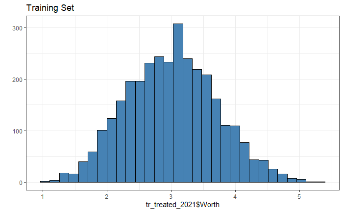

```r
ggplot2::qplot(tr_treated_2021$Worth, main="Training Set") + geom_histogram(colour="black", fill="steelblue") + theme_bw()
```

```r
#The skewness is actually a bit better than the overall data set
skewness(tr_treated_2021$Worth)
```

```
[1] 0.1
```

# 5 Running XGboost Model

To keep things simple with modeling, we’ll turn the training data into simple input variables for `caret::train`, dropping the response variable and converting the data frame to a matrix. Documentation for this approach to XGboost can be found [here.](https://www.kaggle.com/pelkoja/visual-xgboost-tuning-with-caret)

## 5.1 Tuning the Model

### 5.1.1 Initial Non-Tuned Model

Break the data set into x and y inputs with x being a matrix. `"_isBAD"` is a category created by the `Vtreat` package in case you want to identify rows

```r
input_x <- as.matrix(((tr_treated_2021))%>%
   select(-Worth) %>%
   select(!ends_with ("_isBAD")))

input_y <- tr_treated_2021$Worth
```

**XGBoost with Default Hyperparameters:**  
The Variable Importance (`caret::varImp(xgb_base_2021, scale = F`) from the caret package shows the contribution of each variable to the initial model. Since this is untuned, we can expect the percentage imporantance to change as the models iterate through potential hyperparameters.  
*XGBoost documentation can be found for more general models [here.](https://www.kaggle.com/code/rtatman/machine-learning-with-xgboost-in-r/notebook)*

```r
#Defaults for xgboost model
grid_default <- expand.grid(
  nrounds = 100,
  max_depth = 6,
  eta = 0.3,
  gamma = 0,
  colsample_bytree = 1,
  min_child_weight = 1,
  subsample = 1
)

#This is a blank train_control set, this will be updated after
train_control <- caret::trainControl(
  method = "none",
  verboseIter = FALSE, # no training log
  allowParallel = TRUE # FALSE for reproducible results
)

xgb_base_2021 <- caret::train(
  x = input_x,
  y = input_y,
  trControl = train_control,
  tuneGrid = grid_default,
  method = "xgbTree",
  verbose = TRUE
)

caret::varImp(xgb_base_2021, scale = F  )
```

```
xgbTree variable importance

  only 20 most important variables shown (out of 774)
```

|  | Overall |
| --- | --- |
| MD_IP | 0.2311 |
| Pitches_IP | 0.0759 |
| TBF_IP | 0.0587 |
| K_slash_9 | 0.0475 |
| lag_HLD_share | 0.0471 |
| ER_IP | 0.0469 |
| BABIP | 0.0372 |
| TTO_percent_ | 0.0360 |
| SD_IP | 0.0328 |
| lag_SV_share | 0.0260 |

[output cut: 10 more lines]

## 5.2 Further Variable Selection

### 5.2.1 Remove redundant and highly correlated variables

Selection Removal Step 1: Check for high correlations  
Normally, this step is done early, but those steps were reserved for preparing the data

```r
dep_cor1 <- t(as.data.frame(cor(tr_treated_2021[ , colnames(tr_treated_2021) != "Worth"],
                tr_treated_2021$Worth)))
dep_cor1 <-
as.data.frame(t(as.data.frame(dep_cor1)%>%
  select(!starts_with("lag")) %>% #remove lag variables
  select(!contains("_isBAD"))))

dep_cor1 <- tibble::rownames_to_column(dep_cor1,"VARIABLES")%>% #remove indicators for missing data
  filter(V1 > 0.40|V1 < -0.3)

dep_cor1
```

| VARIABLES | V1 |
| --- | --- |
| GS | -0.44 |
| BB_slash_9 | 0.41 |
| Contact_percent_ | -0.31 |
| Contact_percent_oparen_sc_cparen_ | -0.31 |
| TTO_percent_ | 0.42 |
| Contact_percent_oparen_pi_cparen_ | -0.31 |
| BS_IP | 0.42 |
| BB_IP | 0.41 |
| Strikes_IP | 0.45 |
| Pitches_IP | 0.49 |

[output cut: 3 more lines]

```r
dep_cor2 <- colnames(row_to_names(t(dep_cor1),row_number = 1))
```

Let’s Remove variables with high correlation to worth metric, and metrics that are calculated after a player’s performance (such as `WPA`/`RE24`) or redundant (`RS_IP`)

```r
input_x <- as.matrix(((tr_treated_2021))%>%
   select(-Worth) %>% #Remove some variables variables
     select (-RS_IP,-ER_IP,-R_IP,-REW,-RE24,-Clutch,-WPA_slash_LI,-Season #Remove redundant variables or non/weighted variables
) %>%
select(!ends_with ("_isBAD"))) #indicator variable for missing data

input_y <- tr_treated_2021$Worth
```

Run the model on the new dataset to make sure the variable importances look fine

```r
#Note Training parameters were set in initial model set up
xgb_base_2021 <- caret::train(
  x = input_x,
  y = input_y,
  trControl = train_control,
  tuneGrid = grid_default,
  method = "xgbTree",
  verbose = TRUE
)

caret::varImp(xgb_base_2021, scale = F  )
```

```
xgbTree variable importance

  only 20 most important variables shown (out of 766)
```

|  | Overall |
| --- | --- |
| MD_IP | 0.2269 |
| Pitches_IP | 0.0907 |
| TBF_IP | 0.0725 |
| lag_HLD_share | 0.0517 |
| K_slash_9 | 0.0463 |
| E_minus_F | 0.0421 |
| TTO_percent_ | 0.0315 |
| BABIP | 0.0283 |
| SD_IP | 0.0278 |
| lag_SV_share | 0.0257 |

[output cut: 10 more lines]

## 5.3 Model with new data

### 5.3.1 Tuning All Hyperparameters

A tune grid allows us to test a large amount of hyper-parameters and find the model with the lowest RMSE for predictions.  
However, The more values you want to test and the greater the amount of Cross-Fold Validations (`method = "cv"`), the greater the computational time it will take. More information on the specific parameters can be found [here.](https://www.hackerearth.com/practice/machine-learning/machine-learning-algorithms/beginners-tutorial-on-xgboost-parameter-tuning-r/tutorial/)

```r
# maximum number of trees
nrounds <- 1000

# note to start nrounds from 200, as smaller learning rates result in errors so
# big with lower starting points that they'll mess the scales
tune_grid <- expand.grid(
  nrounds = seq(from = 100, to = nrounds, by = 50),
  eta = c(0.01, 0.025, 0.05, 0.075, 0.1),
  max_depth = c(2, 4, 6, 8, 10),
  gamma = 0,
  colsample_bytree = 1,
  min_child_weight = 1,
  subsample = 1
)

tune_control <- caret::trainControl(
  method = "cv", # cross-validation
  number = 5, # with n folds
  ## Note this was # out in the original code
  #index = createFolds(tr_treated$Id_clean), # fix the folds
  verboseIter = FALSE, # no training log
  allowParallel = FALSE # FALSE for reproducible results
)
```

*Running the initial tuning model*

```r
#Note I will be timing these runs to give an estimate on how long this model takes to run
start_time <- Sys.time()

xgb_tune_2021 <- caret::train(
  x = input_x,
  y = input_y,
  trControl = tune_control,
  tuneGrid = tune_grid,
  method = "xgbTree",
  verbose = FALSE
  ,verbosity = 0
)

end_time <- Sys.time()

end_time - start_time
```

```
Time difference of 21 mins
```

*Tuning Plot and Variable Importance*

```r
varImp(xgb_tune_2021, scale = F  )
```

```
xgbTree variable importance

  only 20 most important variables shown (out of 766)
```

|  | Overall |
| --- | --- |
| MD_IP | 0.1491 |
| Pitches_IP | 0.1010 |
| TBF_IP | 0.0806 |
| E_minus_F | 0.0697 |
| SD_IP | 0.0657 |
| gmLI | 0.0580 |
| K_slash_9 | 0.0562 |
| lag_SV_share | 0.0507 |
| TTO_percent_ | 0.0490 |
| lag_HLD_share | 0.0360 |

[output cut: 10 more lines]

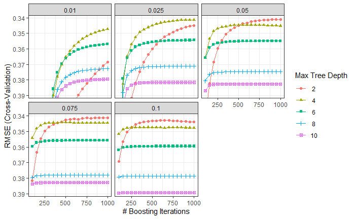

```r
# helper function for the plots
tuneplot <- function(x, probs = .90) {
  ggplot(x) +
    coord_cartesian(ylim = c(quantile(x$results$RMSE, probs = probs), min(x$results$RMSE))) +
    theme_bw()
}

tuneplot(xgb_tune_2021)
```

### 5.3.2 Fine Tuning Model

#### 5.3.2.1 Second Tuning: Maximum Depth and Minimum Child Weight

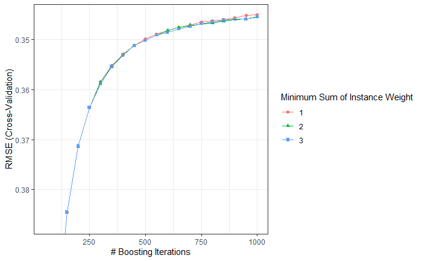

```r
tune_grid2 <- expand.grid(
  nrounds = seq(from = 50, to = nrounds, by = 50),
  eta = xgb_tune_2021$bestTune$eta,
  max_depth = ifelse(xgb_tune_2021$bestTune$max_depth == 2,
    c(xgb_tune_2021$bestTune$max_depth:4),
    xgb_tune_2021$bestTune$max_depth - 1:xgb_tune_2021$bestTune$max_depth + 1),
  gamma = 0,
  colsample_bytree = 1,
  min_child_weight = c(1, 2, 3),
  subsample = 1
)

xgb_tune2_2021 <- caret::train(
  x = input_x,
  y = input_y,
  trControl = tune_control,
  tuneGrid = tune_grid2,
  method = "xgbTree",
  verbose = TRUE
)

tuneplot(xgb_tune2_2021)
```

```r
xgb_tune2_2021$bestTune
```

|  | nrounds | max_depth | eta | gamma | colsample_bytree | min_child_weight | subsample |
| --- | --- | --- | --- | --- | --- | --- | --- |
| 20 | 1000 | 2 | 0.05 | 0 | 1 | 1 | 1 |

```r
varImp(xgb_tune2_2021, scale = F  )
```

```
xgbTree variable importance

  only 20 most important variables shown (out of 766)
```

|  | Overall |
| --- | --- |
| MD_IP | 0.1480 |
| Pitches_IP | 0.1003 |
| TBF_IP | 0.0801 |
| E_minus_F | 0.0694 |
| SD_IP | 0.0654 |
| gmLI | 0.0575 |
| K_slash_9 | 0.0558 |
| lag_SV_share | 0.0503 |
| TTO_percent_ | 0.0487 |
| lag_HLD_share | 0.0358 |

[output cut: 10 more lines]

#### 5.3.2.2 Third Tuning: Column and Row Sampling

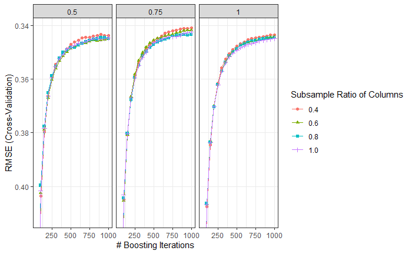

```r
tune_grid3 <- expand.grid(
  nrounds = seq(from = 50, to = nrounds, by = 50),
  eta = xgb_tune_2021$bestTune$eta,
  max_depth = xgb_tune2_2021$bestTune$max_depth,
  gamma = 0,
  colsample_bytree = c(0.4, 0.6, 0.8, 1.0),
  min_child_weight = xgb_tune2_2021$bestTune$min_child_weight,
  subsample = c(0.5, 0.75, 1.0)
)

xgb_tune3_2021 <- caret::train(
  x = input_x,
  y = input_y,
  trControl = tune_control,
  tuneGrid = tune_grid3,
  method = "xgbTree",
  verbose = TRUE
)

tuneplot(xgb_tune3_2021, probs = .95)
```

```r
xgb_tune3_2021$bestTune
```

|  | nrounds | max_depth | eta | gamma | colsample_bytree | min_child_weight | subsample |
| --- | --- | --- | --- | --- | --- | --- | --- |
| 40 | 1000 | 2 | 0.05 | 0 | 0.4 | 1 | 0.75 |

```r
varImp(xgb_tune3_2021, scale = F  )
```

```
xgbTree variable importance

  only 20 most important variables shown (out of 766)
```

|  | Overall |
| --- | --- |
| MD_IP | 0.1500 |
| Pitches_IP | 0.0828 |
| TBF_IP | 0.0668 |
| E_minus_F | 0.0627 |
| K_slash_9 | 0.0483 |
| gmLI | 0.0463 |
| SD_IP | 0.0437 |
| TTO_percent_ | 0.0410 |
| lag_SV_share | 0.0396 |
| lag_HLD_share | 0.0342 |

[output cut: 10 more lines]

#### 5.3.2.3 Fourth Tuning: Gamma

Next, we again pick the best values from previous step, and now will see whether changing the gamma has any effect on the model fit:

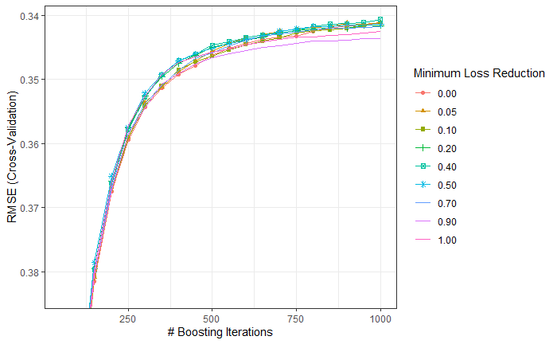

```r
tune_grid4 <- expand.grid(
  nrounds = seq(from = 50, to = nrounds, by = 50),
  eta = xgb_tune_2021$bestTune$eta,
  max_depth = xgb_tune2_2021$bestTune$max_depth,
  gamma = c(0, 0.05,0.1, 0.2,0.4, 0.5, 0.7, 0.9, 1.0),
  colsample_bytree = xgb_tune3_2021$bestTune$colsample_bytree,
  min_child_weight = xgb_tune2_2021$bestTune$min_child_weight,
  subsample = xgb_tune3_2021$bestTune$subsample
)

xgb_tune4_2021 <- caret::train(
  x = input_x,
  y = input_y,
  trControl = tune_control,
  tuneGrid = tune_grid4,
  method = "xgbTree",
  verbose = TRUE
)

tuneplot(xgb_tune4_2021)
```

```r
xgb_tune4_2021$bestTune
```

|  | nrounds | max_depth | eta | gamma | colsample_bytree | min_child_weight | subsample |
| --- | --- | --- | --- | --- | --- | --- | --- |
| 100 | 1000 | 2 | 0.05 | 0.4 | 0.4 | 1 | 0.75 |

```r
varImp(xgb_tune4_2021, scale = F  )
```

```
xgbTree variable importance

  only 20 most important variables shown (out of 766)
```

|  | Overall |
| --- | --- |
| MD_IP | 0.095 |
| Pitches_IP | 0.089 |
| SD_IP | 0.084 |
| TBF_IP | 0.083 |
| E_minus_F | 0.070 |
| TTO_percent_ | 0.054 |
| gmLI | 0.046 |
| lag_HLD_share | 0.044 |
| lag_SV_share | 0.032 |
| K_slash_9 | 0.032 |

[output cut: 10 more lines]

#### 5.3.2.4 Fifth Tuning: Reducing the Learning Rate

Now, we have tuned the hyperparameters and can start reducing the learning rate to get to the final model:

```r
start_time <- Sys.time()

tune_grid5 <- expand.grid(
  nrounds = seq(from = 100, to = 10000, by = 75),
   eta = c(0.01, 0.015, 0.025,0.035, 0.05,0.75, 0.1),
  max_depth = xgb_tune2_2021$bestTune$max_depth,
  gamma = xgb_tune4_2021$bestTune$gamma,
  colsample_bytree = xgb_tune3_2021$bestTune$colsample_bytree,
  min_child_weight = xgb_tune2_2021$bestTune$min_child_weight,
  subsample = xgb_tune3_2021$bestTune$subsample
)



xgb_tune5_2021 <- caret::train(
  x = input_x,
  y = input_y,
  trControl = tune_control,
  tuneGrid = tune_grid5,
  method = "xgbTree",
  verbose = TRUE
)

#tuneplot(xgb_tune5_2021)

end_time <- Sys.time()

end_time - start_time
```

```
Time difference of 17 mins
```

```r
xgb_tune5_2021$bestTune
```

|  | nrounds | max_depth | eta | gamma | colsample_bytree | min_child_weight | subsample |
| --- | --- | --- | --- | --- | --- | --- | --- |
| 254 | 9100 | 2 | 0.015 | 0.4 | 0.4 | 1 | 0.75 |

```r
varImp(xgb_tune5_2021, scale = F  )
```

```
xgbTree variable importance

  only 20 most important variables shown (out of 766)
```

|  | Overall |
| --- | --- |
| MD_IP | 0.1032 |
| Pitches_IP | 0.0866 |
| E_minus_F | 0.0624 |
| TBF_IP | 0.0617 |
| SD_IP | 0.0525 |
| gmLI | 0.0472 |
| K_slash_9 | 0.0437 |
| TTO_percent_ | 0.0425 |
| lag_SV_share | 0.0421 |
| lag_HLD_share | 0.0314 |

[output cut: 10 more lines]

#### 5.3.2.5 Fitting Final Model

```r
(final_grid_2021 <- expand.grid(
  nrounds = xgb_tune5_2021$bestTune$nrounds,
  eta = xgb_tune5_2021$bestTune$eta,
  max_depth = xgb_tune5_2021$bestTune$max_depth,
  gamma = xgb_tune5_2021$bestTune$gamma,
  colsample_bytree = xgb_tune5_2021$bestTune$colsample_bytree,
  min_child_weight = xgb_tune5_2021$bestTune$min_child_weight,
  subsample = xgb_tune5_2021$bestTune$subsample
))
```

| nrounds | eta | max_depth | gamma | colsample_bytree | min_child_weight | subsample |
| --- | --- | --- | --- | --- | --- | --- |
| 9100 | 0.015 | 2 | 0.4 | 0.4 | 1 | 0.75 |

```r
(xgb_model_2021 <- caret::train(
  x = input_x,
  y = input_y,
  trControl = train_control,
  tuneGrid = final_grid_2021,
  method = "xgbTree",
  verbose = TRUE
))
```

```
eXtreme Gradient Boosting

3197 samples
 766 predictor

No pre-processing
Resampling: None
```

```r
varImp(xgb_model_2021, scale = F  )
```

```
xgbTree variable importance

  only 20 most important variables shown (out of 766)
```

|  | Overall |
| --- | --- |
| MD_IP | 0.0790 |
| Pitches_IP | 0.0752 |
| SD_IP | 0.0685 |
| TBF_IP | 0.0677 |
| E_minus_F | 0.0599 |
| TTO_percent_ | 0.0472 |
| gmLI | 0.0429 |
| lag_SV_share | 0.0422 |
| Pulls_IP | 0.0401 |
| K_slash_9 | 0.0390 |

[output cut: 10 more lines]

## 5.4 Model Performance

### 5.4.1 Checking Model on Test Split Data

We don’t need to look too closely at are training data as Xgboost will heavily overfit the model based on that data. The more important part is how the model performs on in predicting our Test Sample that was not included.

```r
y_pred_test <- predict(xgb_model_2021, data.matrix(te_treated_2021))

test_stats= cbind((te_treated_2021$Worth),y_pred_test)

test_statsR2 = cor(test_stats[,1],test_stats[,2])^2

print(test_statsR2)
```

```
[1] 0.79
```

```r
y_pred_train <- predict(xgb_model_2021, data.matrix(tr_treated_2021))

train_stats = cbind((tr_treated_2021$Worth),y_pred_train)

train_statsR2 = cor(train_stats[,1],train_stats[,2])^2

print(train_statsR2)
```

```
[1] 0.94
```

```r
#test dataset
x <- select(te_treated_2021, -Worth)
y <- (te_treated_2021$Worth)

(xgb_model_rmse <- ModelMetrics::rmse(y, predict(xgb_model_2021, newdata = x)))
```

```
[1] 0.33
```

```r
holdout_x <- select(tr_treated_2021, -Worth)
holdout_y <- tr_treated_2021$Worth

(xgb_model_rmse <- ModelMetrics::rmse(holdout_y, predict(xgb_model_2021, newdata = holdout_x)))
```

```
[1] 0.18
```

#### 5.4.1.1 Graphical Representation of Model

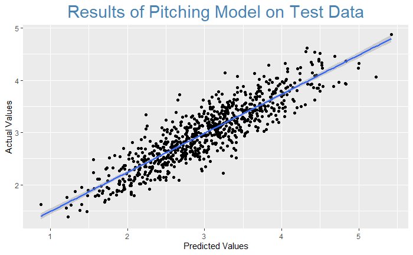

```r
ggplot2::ggplot() +
  aes(x = test_stats[,1], y = test_stats[,2]) +
  geom_jitter() +
  xlab("Predicted Values") +
  ylab("Actual Values") +
  ggtitle("Results of Pitching Model on Test Data")+
  theme(plot.title = element_text(hjust = 0.5,size = 22,color ="steel blue"))+
  geom_smooth(method = "lm")
```

# 6 Creating 2022 Projections from Model

## 6.1 Re-fit model for Important Variables

Step 1: Only keep variables with high enough importance in model

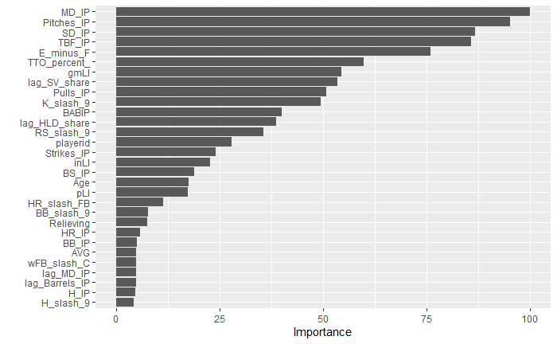

```r
vip(xgb_model_2021, num_features = 30)  # 10 is the default, 30 gives a visual on the top 30 most important features of the model
```

```r
unscalevi = vi(xgb_model_2021, method="model") #shows the numbers behind the plot

unscalevi$Importance_perc = with(unscalevi,Importance/sum(Importance)) #adds percentages

unscalevi # importance by variables
```

| Variable | Importance | Importance_perc |
| --- | --- | --- |
| MD_IP | 100.0000 | 0.0789644 |
| Pitches_IP | 95.2473 | 0.0752115 |
| SD_IP | 86.7883 | 0.0685319 |
| TBF_IP | 85.7655 | 0.0677243 |
| E_minus_F | 75.8868 | 0.0599236 |
| TTO_percent_ | 59.8248 | 0.0472403 |
| gmLI | 54.3677 | 0.0429311 |
| lag_SV_share | 53.5002 | 0.0422461 |
| Pulls_IP | 50.7779 | 0.0400965 |
| K_slash_9 | 49.3521 | 0.0389706 |

[output cut: 756 more lines]

```r
variables_to_keep_2021 = subset(unscalevi, Importance_perc > 0.0010) %>% select(Variable) #Keep Variables that explain at least a small amount [0.1%] of the model. This is a low threshold for inclusion ,but you can adjust this

variables_to_keep_2021b = t(variables_to_keep_2021)

variables_to_keep_2022 = colnames(row_to_names(variables_to_keep_2021b,row_number = 1))

tr_treated_2022 = tr_treated_2021 %>%  select(Worth,one_of(variables_to_keep_2022),starts_with("Team_lev_x_")) #keep modeled important variables along with team indicator variables

te_treated_2022 = te_treated_2021 %>%  select(Worth,one_of(variables_to_keep_2022),starts_with("Team_lev_x_"))

input_x_2022 = as.matrix(select(tr_treated_2022, -Worth))

input_y_2022 = tr_treated_2022$Worth
```

```r
(final_grid_2021 <- expand.grid(
  nrounds = xgb_tune5_2021$bestTune$nrounds,
  eta = xgb_tune5_2021$bestTune$eta,
  max_depth = xgb_tune5_2021$bestTune$max_depth,
  gamma = xgb_tune5_2021$bestTune$gamma,
  colsample_bytree = xgb_tune5_2021$bestTune$colsample_bytree,
  min_child_weight = xgb_tune5_2021$bestTune$min_child_weight,
  subsample = xgb_tune5_2021$bestTune$subsample
))
```

| nrounds | eta | max_depth | gamma | colsample_bytree | min_child_weight | subsample |
| --- | --- | --- | --- | --- | --- | --- |
| 9100 | 0.015 | 2 | 0.4 | 0.4 | 1 | 0.75 |

```r
(xgb_model_2022 <- caret::train(
  x = input_x_2022,
  y = input_y_2022,
  trControl = train_control,
  tuneGrid = final_grid_2021,
  method = "xgbTree",
  verbose = TRUE
))
```

```
eXtreme Gradient Boosting

3197 samples
  93 predictor

No pre-processing
Resampling: None
```

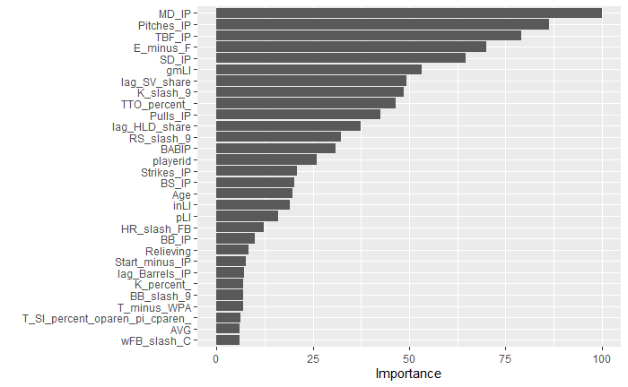

```r
vip(xgb_model_2022, num_features = 30)
```

```r
unscalevi24 = vi(xgb_model_2022, method="model")

unscalevi24$Importance_perc = with(unscalevi24,Importance/sum(Importance))

unscalevi24
```

| Variable | Importance | Importance_perc |
| --- | --- | --- |
| MD_IP | 100.0000 | 0.0936031 |
| Pitches_IP | 86.3794 | 0.0808538 |
| TBF_IP | 79.1538 | 0.0740905 |
| E_minus_F | 70.0686 | 0.0655864 |
| SD_IP | 64.7207 | 0.0605806 |
| gmLI | 53.1248 | 0.0497265 |
| lag_SV_share | 49.2727 | 0.0461208 |
| K_slash_9 | 48.5884 | 0.0454803 |
| TTO_percent_ | 46.5195 | 0.0435437 |
| Pulls_IP | 42.4875 | 0.0397696 |

[output cut: 83 more lines]

```r
# Save work for later prediction

save(xgb_model_2022,file = '2022_Pitching6x6_Model.Rdata')

pitching6x6 = xgb_model_2022

pitchinginput6x6 = input_x_2022
```

## 6.2 Get 2022 list of players

### 6.2.1 Arrange the Data so the Columns are in the exact order as the model

First let’s prepare a file for predicting based on our model object

```r
variableslag6x= row_to_names(as.data.frame(t(variables_to_keep_2022)),row_number = 1)  %>% select (starts_with("lag"))

variables_nolag6x = (owmr::remove_prefix(variableslag6x,"lag" , sep = "_"))

Data_Predict_2022a6x = total_treated_2021_pitching %>% select (one_of(colnames(variables_nolag6x)),Season,playerid)

colnames(Data_Predict_2022a6x) <- paste0("lag_", colnames(Data_Predict_2022a6x))

Data_Predict_2022b6x = total_treated_2021_pitching %>% select (one_of(colnames(variables_nolag6x)))
colnames(Data_Predict_2022b6x) = colnames(variableslag6x)

variables_to_keep_2022_nolag6x = total_treated_2021_pitching %>% select(one_of(variables_to_keep_2022),Season,playerid,starts_with("Team_lev_x_"))%>% select(-one_of(colnames(Data_Predict_2022b6x)))


Data_predict_20226x = sqldf(
  "
  select a.*,b.* from
  Data_Predict_2022a6x a,
  variables_to_keep_2022_nolag6x b
  on b.playerid = a.lag_playerid
  and b.Season = a.lag_Season
  "
) %>% select(-lag_playerid,lag_Season) %>%
  filter(Season == 2021) %>%
  select(one_of(variables_to_keep_2022),starts_with("Team_lev_x_"))
```

## 6.3 Create Predictions for Model

### 6.3.1 Run Projections on Players who Played in 2021

This is the raw prediction score per IP for each pitcher

```r
pitching_predictions6x = as.data.frame(predict(xgb_model_2022,Data_predict_20226x))

names(pitching_predictions6x) = c("Predict_Score")

Data_predict_2022_w_Pitching_Predictions6x = cbind(Data_predict_2022,pitching_predictions6x) %>% select(playerid,Predict_Score)

head(Data_predict_2022_w_Pitching_Predictions6x)
```

|  | playerid | Predict_Score |
| --- | --- | --- |
| 1 | 1247 | 4.7 |
| 2 | 1581 | 3.7 |
| 3 | 1890 | 2.7 |
| 4 | 1943 | 1.8 |
| 5 | 2036 | 1.9 |
| 6 | 2233 | 1.4 |

```r
NA
```

### 6.3.2 Load in Latest 2022 Projections for Innings Pitched

Downloaded from FanGraphs [here.](https://www.fangraphs.com/projections.aspx?pos=all&stats=pit&type=atc&team=0&lg=all&players=0)

```r
Latest_2022_pitchingdata_FP = read_csv("FanGraph_Fantasy_Baseball_Pitching.csv")
Latest_2022_pitchingdata_FP
```

| Name | Team | GS | G | IP | W | L | QS | SV | HLD | H | ER | HR | SO | BB | WHIP | K/9 | BB/9 | ERA | FIP | WAR | RA9-WAR | ADP | InterSD | InterSK | IntraSD | playerid |
| --- | --- | --- | --- | --- | --- | --- | --- | --- | --- | --- | --- | --- | --- | --- | --- | --- | --- | --- | --- | --- | --- | --- | --- | --- | --- | --- |
| Corbin Burnes | MIL | 29 | 29 | 171 | 12 | 7 | 16 | 0 | 0 | 131 | 58 | 17 | 221 | 48 | 1.04 | 11.6 | 2.5 | 3.1 | 2.7 | 5.3 | 4.9 | 10.8 | 3.96 | -0.20 | 1.40 | 19361 |
| Jacob deGrom | NYM | 24 | 24 | 145 | 10 | 5 | 16 | 0 | 0 | 103 | 41 | 15 | 207 | 35 | 0.95 | 12.8 | 2.2 | 2.6 | 2.4 | 5.1 | 4.7 | 19.7 | 5.73 | -0.03 | 1.93 | 10954 |
| Gerrit Cole | NYY | 30 | 30 | 189 | 16 | 8 | 18 | 0 | 0 | 147 | 66 | 26 | 250 | 47 | 1.03 | 11.9 | 2.2 | 3.1 | 3.2 | 5.0 | 5.2 | 7.1 | 4.32 | 0.35 | 1.57 | 13125 |
| Shane Bieber | CLE | 28 | 28 | 174 | 13 | 8 | 17 | 0 | 0 | 143 | 64 | 22 | 215 | 47 | 1.10 | 11.1 | 2.4 | 3.3 | 3.2 | 4.4 | 4.5 | 31.2 | 7.45 | -1.70 | 1.08 | 19427 |
| Zack Wheeler | PHI | 28 | 28 | 179 | 12 | 8 | 16 | 0 | 0 | 158 | 70 | 20 | 183 | 46 | 1.14 | 9.2 | 2.3 | 3.5 | 3.4 | 4.4 | 4.0 | 31.0 | 4.22 | 0.47 | 0.84 | 10310 |
| Brandon Woodruff | MIL | 31 | 31 | 183 | 12 | 9 | 18 | 0 | 0 | 151 | 68 | 22 | 205 | 49 | 1.09 | 10.1 | 2.4 | 3.3 | 3.4 | 4.2 | 4.5 | 21.2 | 3.65 | 0.19 | 1.09 | 16162 |
| Aaron Nola | PHI | 30 | 31 | 181 | 12 | 9 | 14 | 0 | 0 | 158 | 75 | 25 | 209 | 49 | 1.14 | 10.4 | 2.4 | 3.7 | 3.6 | 4.2 | 3.5 | 41.0 | 5.00 | -0.50 | 0.95 | 16149 |
| Walker Buehler | LAD | 31 | 31 | 190 | 13 | 7 | 18 | 0 | 0 | 161 | 75 | 25 | 195 | 52 | 1.12 | 9.2 | 2.4 | 3.5 | 3.7 | 3.8 | 3.8 | 18.6 | 6.48 | -0.42 | 0.98 | 19374 |
| Max Scherzer | NYM | 28 | 28 | 172 | 12 | 8 | 16 | 0 | 0 | 135 | 62 | 24 | 217 | 45 | 1.05 | 11.4 | 2.3 | 3.3 | 3.4 | 3.8 | 3.7 | 19.7 | 4.40 | -1.80 | 1.28 | 3137 |
| Lucas Giolito | CHW | 30 | 30 | 180 | 12 | 8 | 15 | 0 | 0 | 148 | 75 | 27 | 208 | 57 | 1.14 | 10.4 | 2.9 | 3.7 | 3.8 | 3.7 | 3.6 | 44.2 | 3.74 | 1.34 | 0.96 | 15474 |

[output cut: 807 more lines]

```r
NA
```

As you can see from the chart below there aren’t many elite pitchers in the 87+ Predict score range.

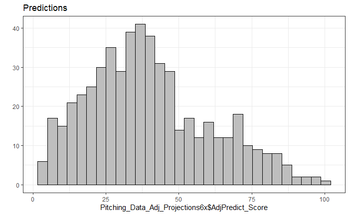

```r
Pitching_Data_NonAdj_Projections6x = sqldf(
  "
  select a.*,b.Predict_Score
  from Latest_2022_pitchingdata_FP a
  left join
  Data_predict_2022_w_Pitching_Predictions6x b
  on a.playerid = b.playerid
  "
) %>% filter(ADP<370 | is.na(Predict_Score)==F)


Pitching_Data_Adj_Projections6x =
Pitching_Data_NonAdj_Projections6x %>%
  mutate(
    Avg_IP = 60,
    AdjPredict_Score_raw = ifelse(is.na(Predict_Score),NA,Predict_Score*(IP/Avg_IP)),
    max_predscore= max(AdjPredict_Score_raw,na.rm = T),
    AdjPredict_Score = ifelse (is.na(AdjPredict_Score_raw),NA,AdjPredict_Score_raw *100/max_predscore),
    WAR_rank = order(order(rank(WAR,ties.method = 'average'),decreasing = TRUE)),
    AdjPredict_Score_Rank = order(order(rank(AdjPredict_Score,ties.method = 'average'),decreasing = TRUE))-sum(is.na(AdjPredict_Score)),
        Ranks_Above_ADP = ADP - AdjPredict_Score_Rank
  ) %>% select (Name,ADP,WAR, WAR_rank,AdjPredict_Score ,AdjPredict_Score_Rank,Ranks_Above_ADP)




ggplot2::qplot(Pitching_Data_Adj_Projections6x$AdjPredict_Score, main="Predictions") + geom_histogram(colour="black", fill="grey") + theme_bw()
```

# 7 2022 Projections Full

## 7.1 Table of Pitching Projections (Players who Didn’t Play in 2021 - Recieve an NA)

AdjPredict_Score are normalized to 100

```r
tableexport =
Pitching_Data_Adj_Projections6x %>%
  arrange (ADP,WAR) %>%
  kbl() %>%
 kable_material(c("striped", "hover","condensed","responsive"),full_width = F,fixed_thead = T)

save_kable(tableexport,file = "Pitching6x6.html")

#tableexport
```

This is a better formatted Table

```r
ft_dt <- Pitching_Data_Adj_Projections6x[1:nrow(Pitching_Data_Adj_Projections6x), 1:ncol(Pitching_Data_Adj_Projections6x)] %>%
  filter(AdjPredict_Score_Rank>0)%>%  arrange((AdjPredict_Score_Rank))

ft_dt$ADP <- color_tile("white", "red")(ft_dt$ADP)

ft_dt$WAR <- color_bar("lightblue")(ft_dt$WAR)

ft_dt$AdjPredict_Score<- color_bar("lightblue")(ft_dt$AdjPredict_Score)

ft_dt$WAR_Rank <- color_tile("green","orange")(ft_dt$WAR_rank)

ft_dt$Predict_Rank <- color_tile("green","orange")(ft_dt$AdjPredict_Score_Rank)


ft_dt$Ranks_Above_ADP <-
  ifelse(
  ft_dt$Ranks_Above_ADP < 0,
  cell_spec(round(ft_dt$Ranks_Above_ADP,2), color = "red", italic = T),
  cell_spec(round(ft_dt$Ranks_Above_ADP,2), color = "green", italic = T)
)


ft_dt2 <- ft_dt[c("Name", "ADP", "WAR", "AdjPredict_Score", "WAR_Rank","Predict_Rank","Ranks_Above_ADP")]



table_export =
kbl(ft_dt2, escape = F) %>%
 kable_material(c("striped", "hover","condensed","responsive"),full_width = F,fixed_thead = T) %>%   column_spec(6, width = "3cm") %>%
  add_header_above(c(" ", "Scores" = 3, "Ranks" = 2," "))

save_kable(table_export,file = "Pitching6x6_updated.html")

table_export
```

| Name | Scores ADP | Scores WAR | Scores AdjPredict_Score | Ranks WAR_Rank | Ranks Predict_Rank | Ranks_Above_ADP |
| --- | --- | --- | --- | --- | --- | --- |
| Eduardo Rodriguez | 150.1 | 3.5 | 100.0 | 15 | 1 | 149.1 |
| Brady Singer | 492.4 | 2.2 | 97.1 | 53 | 2 | 490.4 |
| Dylan Cease | 81.2 | 3.3 | 95.4 | 20 | 3 | 78.2 |
| Josiah Gray | 290.7 | 1.6 | 93.1 | 89 | 4 | 286.7 |
| José Quintana | 575.5 | 1.0 | 92.8 | 143 | 5 | 570.5 |
| Shane Bieber | 31.2 | 4.4 | 91.9 | 4 | 6 | 25.2 |
| Tarik Skubal | 197.6 | 2.0 | 90.9 | 61 | 7 | 190.6 |
| Aaron Nola | 41.0 | 4.2 | 88.3 | 7 | 8 | 33 |
| Nick Pivetta | 350.8 | 1.7 | 87.5 | 86 | 9 | 341.8 |
| Alek Manoah | 93.0 | 2.8 | 87.5 | 33 | 10 | 83 |
| Shane McClanahan | 109.6 | 2.6 | 87.3 | 40 | 11 | 98.6 |
| Luis Castillo | 103.2 | 3.3 | 85.4 | 21 | 12 | 91.2 |
| Zac Gallen | 154.3 | 2.3 | 85.2 | 50 | 13 | 141.3 |
| Logan Webb | 69.9 | 3.7 | 84.7 | 11 | 14 | 55.9 |
| Tyler Mahle | 132.2 | 2.6 | 84.7 | 39 | 15 | 117.2 |
| Logan Gilbert | 161.8 | 2.2 | 84.6 | 52 | 16 | 145.8 |
| Corbin Burnes | 10.8 | 5.3 | 84.5 | 1 | 17 | -6.2 |
| Jon Gray | 236.9 | 2.3 | 84.4 | 51 | 18 | 218.9 |
| Brad Keller | 582.1 | 1.6 | 83.8 | 91 | 19 | 563.1 |
| Germán Márquez | 261.7 | 2.9 | 83.5 | 29 | 20 | 241.7 |
| Walker Buehler | 18.6 | 3.8 | 80.5 | 8 | 21 | -2.4 |
| Yusei Kikuchi | 301.3 | 1.7 | 80.2 | 83 | 22 | 279.3 |
| Jesús Luzardo | 289.5 | 0.8 | 79.8 | 158 | 23 | 266.5 |
| Gerrit Cole | 7.1 | 5.0 | 79.0 | 3 | 24 | -16.9 |
| Luis Garcia | 144.7 | 2.0 | 78.9 | 64 | 25 | 119.7 |
| Sean Manaea | 141.4 | 2.8 | 78.9 | 31 | 26 | 115.4 |
| Freddy Peralta | 54.0 | 3.6 | 78.8 | 12 | 27 | 27 |
| Trevor Rogers | 92.9 | 3.1 | 78.7 | 25 | 28 | 64.9 |
| Lucas Giolito | 44.2 | 3.7 | 77.9 | 10 | 29 | 15.2 |
| Michael Kopech | 161.1 | 2.5 | 77.9 | 43 | 30 | 131.1 |

[output cut: 497 more lines]

```r
NA
NA
NA
NA
NA
NA
```